# MiDAS_course

Miriam Peces, Sofie Zacho Vestergaard, Marta Nierychlo

2026-06-09, Aalborg, Denmark

# Questions for the MiDAS course - ampvis hands on. Whenever you encounter “…” it means you should fill something in there.

## Only do ONCE!!!!

```r
install.packages("remotes")
remotes::install_github("kasperskytte/ampvis2")
install.packages("tidyverse")
```

## Load the packages

```r
library(ampvis2)
library(tidyverse)
```

## Set your working directory - only if you did not open script from the downloaded folder

```r
#setwd("")
```

## Load the data into an ampvis object

```r
d_midas <- amp_load(otutable = "data/ASVtable.tsv",
              taxonomy = "data/ASVs.R1.midas53.sintax",
              metadata = "data/metadata_midascourse.txt")
```

# Inspect the data - get a summary of the ampvis object

```r
d_midas
```

```
## ampvis2 object with 3 elements.
## Summary of OTU table:
##      Samples         OTUs  Total#Reads    Min#Reads    Max#Reads Median#Reads
##          141        12229      6316036          886       127366        42719
##    Avg#Reads
##     44794.58
##
## Assigned taxonomy:
##       Kingdom        Phylum         Class         Order        Family
##   12229(100%) 12159(99.43%) 12117(99.08%) 12019(98.28%) 11839(96.81%)
##         Genus       Species
## 11114(90.88%)  8897(72.75%)
##
## Metadata variables: 5
##  SampleID, SampleContent, SampleSite, SampleDate, Month
```

# Investigate rarefaction curve

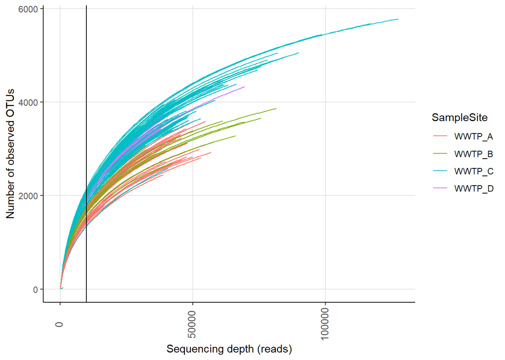

```r
amp_rarecurve(d_midas,
              color_by = 'SampleSite') +
  geom_vline(xintercept = 10000)
```

## plot the number of reads for each sample

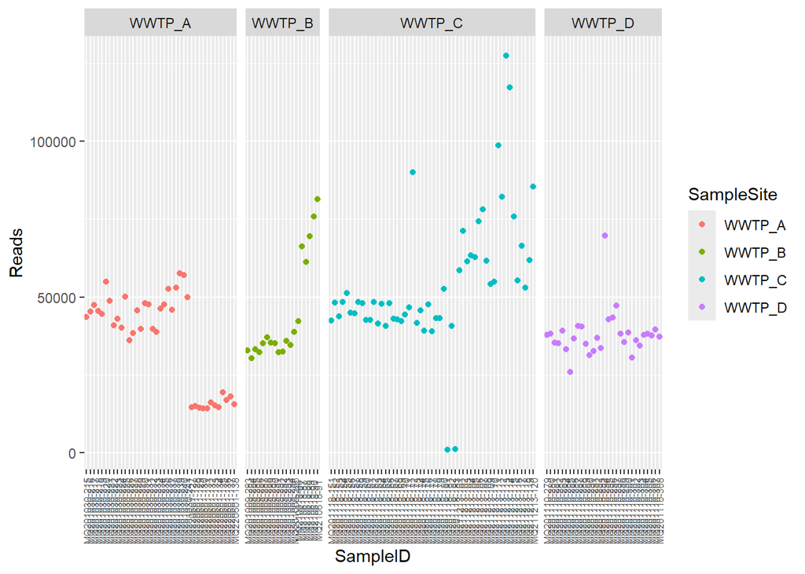

```r
ggplot( amp_alpha_diversity(d_midas))+
  geom_point(aes(x= SampleID, y = Reads, color=SampleSite)) +
  facet_grid(~ SampleSite, scales = 'free_x', space = 'free') +
  theme(axis.text.x = element_text(angle = 90, size=6, vjust= 0.5))
```

# Filter data: Remove low read samples and normalise data

```r
dsn_midas <- amp_subset_samples(d_midas,
                                minreads = 10000, # remove samples with less than 10000 reads
                                normalise = TRUE)
```

```
## 2 samples and 11 OTUs have been filtered
## Before: 141 samples and 12229 OTUs
## After: 139 samples and 12218 OTUs
```

Questions to answer

Q1 What are the top 25 most abundant genera? hint: look into amp_heatmap()

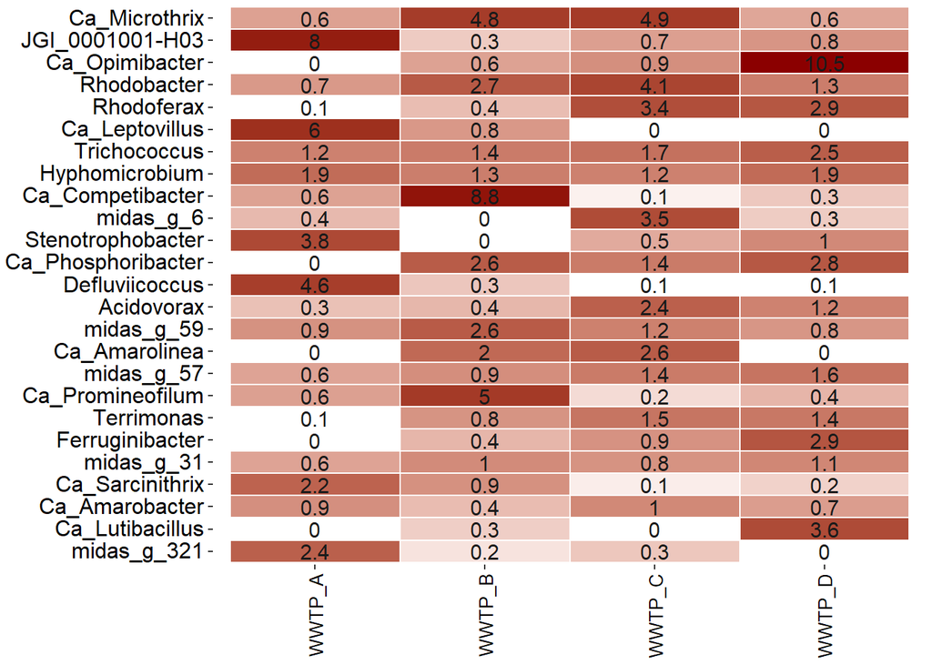

```r
amp_heatmap(dsn_midas,
            normalise = F,
            group_by = 'SampleSite',
            tax_show = 25,
            tax_aggregate = 'Genus',
            color_vector = c('white', 'darkred'))
```

Q2 What are the top 25 most abundant species? And what genera are these belonging to (plot these with the species)?

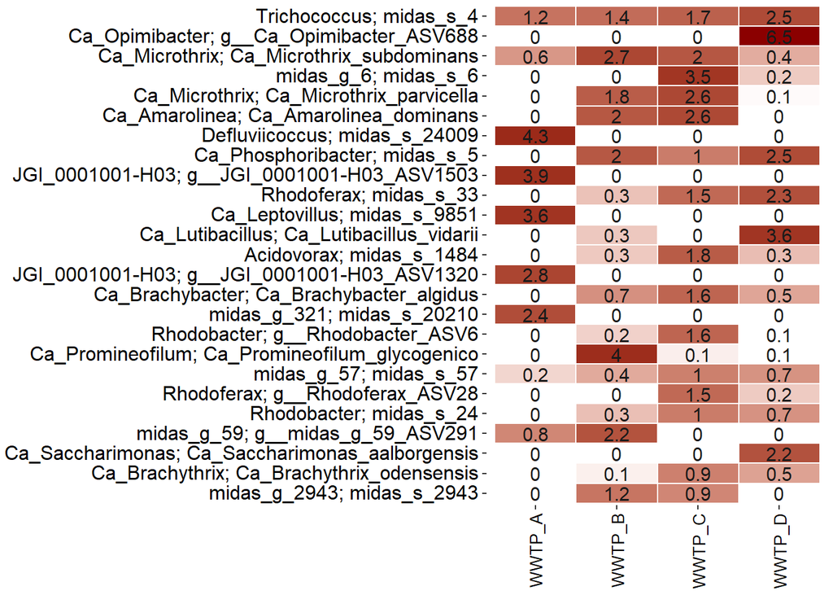

```r
amp_heatmap(dsn_midas,
            normalise = F,
            group_by = 'SampleSite',
            tax_show = 25,
            tax_aggregate = 'Species',
            tax_add = 'Genus',
            color_vector = c('white', 'darkred'))
```

Addition Q3 - sort by a specific plant

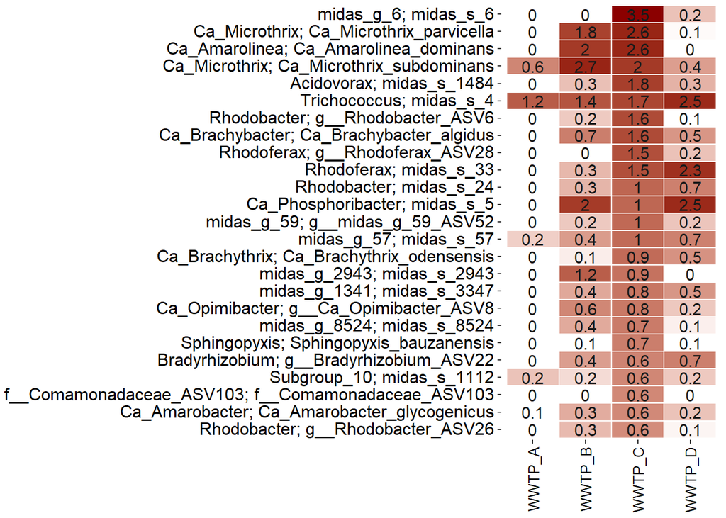

```r
amp_heatmap(dsn_midas,
            normalise = F,
            group_by = 'SampleSite',
            tax_show = 25,
            tax_aggregate = 'Species',
            sort_by = 'WWTP_C',
            tax_add = 'Genus',
            color_vector = c('white', 'darkred'))
```

Q3 Try to save the heatmap from before

```r
heatmap <- amp_heatmap(dsn_midas,
            normalise = F,
            group_by = 'SampleSite',
            tax_show = 25,
            tax_aggregate = 'Species',
            tax_add = 'Genus',
            color_vector = c('white', 'darkred'))

ggsave("heatmap.png", heatmap,
       width = 8, height = 6 #change to fit your needs
       )
```

Q4. Perform an ordination to compare the microbial structures of the different WWTPs.

```
## 10898 OTUs not present in more than 0.1% relative abundance in any sample have been filtered
## Before: 12218 OTUs
## After: 1320 OTUs
```

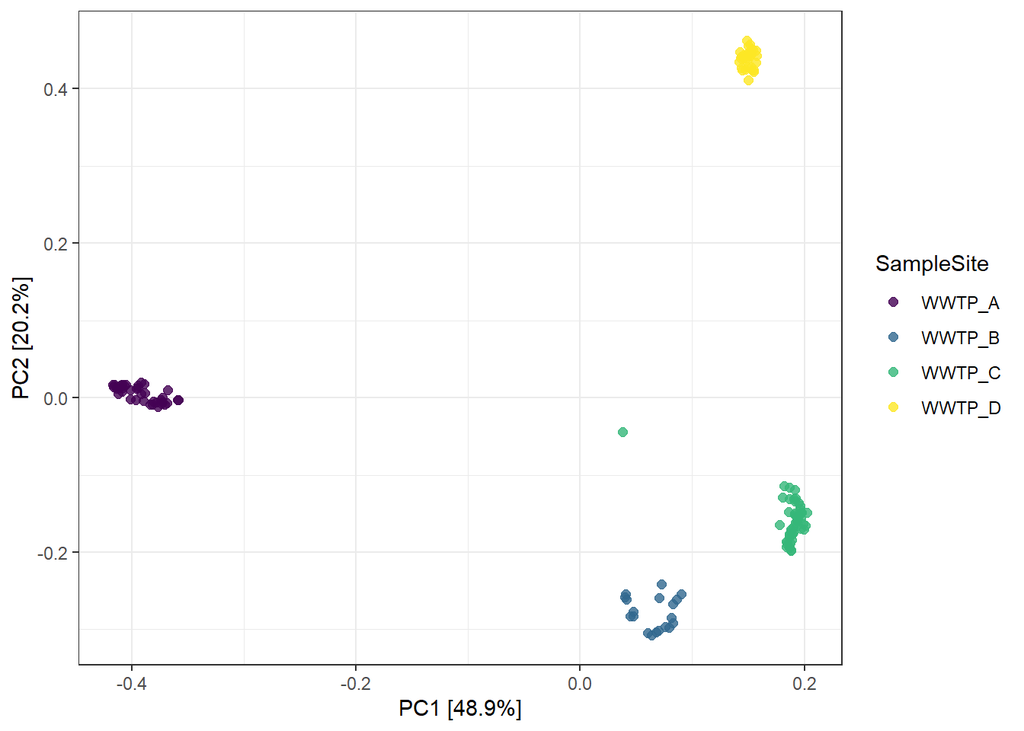

```r
amp_ordinate(data = dsn_midas,
             transform = "Hellinger",
             type = "PCA",
             sample_color_by = "SampleSite") +
  scale_colour_viridis_d() + # example how to customise with ggplot
  theme_bw() # example how to customise with ggplot
```

Compare to silva taxonomy Q5 How many of the ASVs are classified at genus and species level using silva? hint: amp_load() with silva tax

```r
d_silva <- amp_load(otutable = "data/ASVtable.tsv",
              taxonomy = "data/ASVs_SILVA_138.2.R1.sintax",
              metadata = "data/metadata_midascourse.txt")

dsn_silva <- amp_subset_samples(d_silva,
                                minreads = 10000, # remove samples with less than 10000 reads
                                normalise = TRUE)
```

```
## 2 samples and 11 OTUs have been filtered
## Before: 141 samples and 12229 OTUs
## After: 139 samples and 12218 OTUs
```

```r
dsn_silva
```

```
## ampvis2 object with 3 elements.
## Summary of OTU table:
## Samples    OTUs
##     139   12218
## (The read counts have been normalised)
##
## Assigned taxonomy:
##       Kingdom        Phylum         Class         Order        Family
##   12217(100%) 11574(94.73%) 10879(89.04%)  9773(79.99%)  7445(60.93%)
##         Genus       Species
##  3779(30.93%)    132(1.08%)
##
## Metadata variables: 5
##  SampleID, SampleContent, SampleSite, SampleDate, Month
```

Q6 What are the most abundant 25 genera using silva? Compare to MiDAS taxonomic assignment

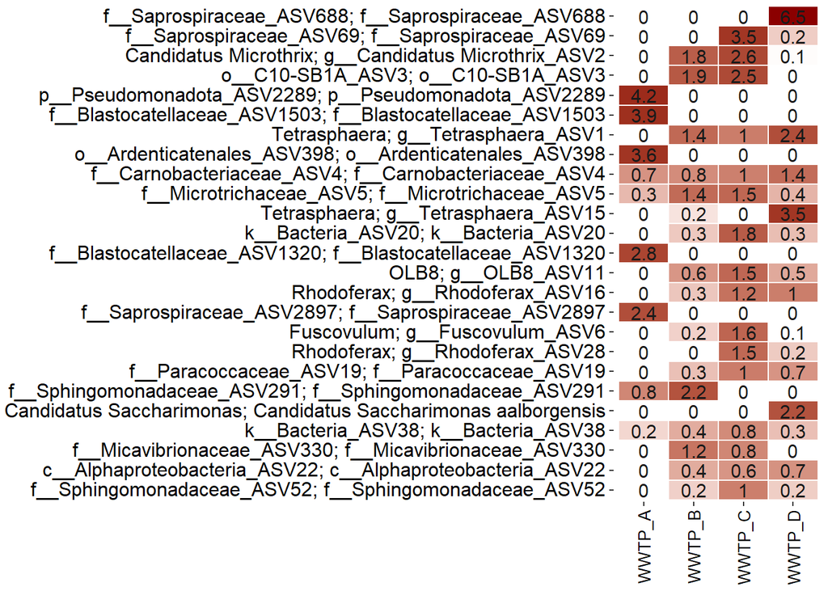

```r
amp_heatmap(dsn_silva,
            normalise = F,
            group_by = 'SampleSite',
            tax_show = 25,
            tax_aggregate = 'Species',
            tax_add = 'Genus',
            color_vector = c('white', 'darkred'))
```

Q7 Make a timeseries plot for Ca. Phosphoribacter and Ca. Accumulibacter in Randers? hint: look into amp_subset_taxa(), amp_subset_sample(), amp_time_series()

```r
subset <- amp_subset_taxa(data = dsn_midas, tax_vector = c("g__Ca_Phosphoribacter", "g__Ca_Accumulibacter")) %>%
  amp_subset_samples(SampleSite == "WWTP_C")
```

```
## 12169 OTUs have been filtered
## Before: 12218 OTUs
## After: 49 OTUs
```

```
## 88 samples and 3 OTUs have been filtered
## Before: 139 samples and 49 OTUs
## After: 51 samples and 46 OTUs
```

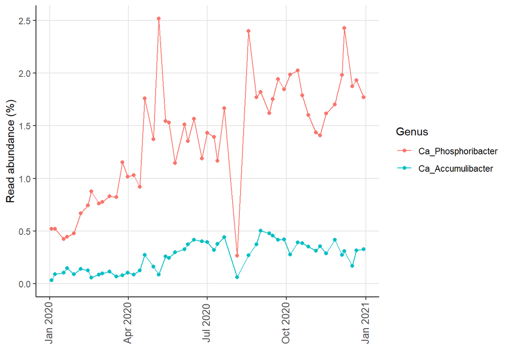

```r
subset$metadata$SampleDate <- as.Date(subset$metadata$SampleDate, format = c("%d/%m/%Y"))

amp_time_series(subset,
                time_variable = "SampleDate",
                tax_aggregate = "Genus",
                normalise = FALSE)
```

Q8 Make a timeseries plot for a species and plant of your choice

```r
subset <- amp_subset_taxa(data = dsn_midas, tax_vector = c("g__Zoogloea")) %>%
  amp_subset_samples(SampleSite == "WWTP_C")
```

```
## 12209 OTUs have been filtered
## Before: 12218 OTUs
## After: 9 OTUs
```

```
## 88 samples and 0 OTUs have been filtered
## Before: 139 samples and 9 OTUs
## After: 51 samples and 9 OTUs
```

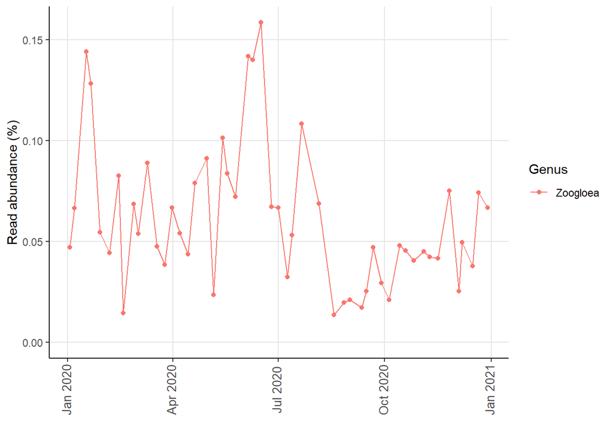

```r
subset$metadata$SampleDate <- as.Date(subset$metadata$SampleDate, format = c("%d/%m/%Y"))

amp_time_series(subset,
                time_variable = "SampleDate",
                tax_aggregate = "Genus",
                normalise = FALSE)
```

# extra questions

Qe1-a Make an ordination plot for all plants - Try different ordinations, e.g PCoA based on bray-curtis distance hint: look into amp_ordinate()

```r
amp_ordinate(dsn_midas,
             sample_color_by = 'SampleSite')
```

```
## 10898 OTUs not present in more than 0.1% relative abundance in any sample have been filtered
## Before: 12218 OTUs
## After: 1320 OTUs
```

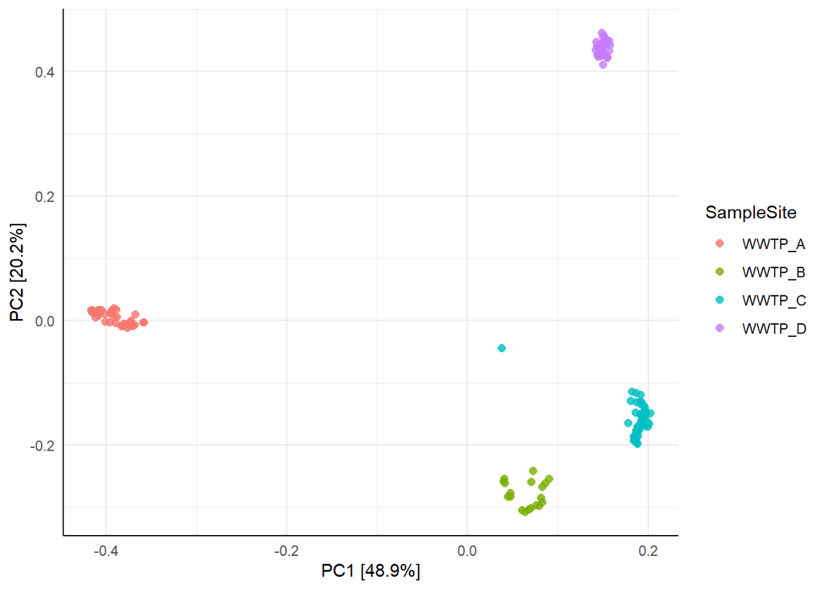

```r
amp_ordinate(dsn_midas,
             sample_color_by = 'SampleSite',
             type = 'PCoA',
             distmeasure = 'Bray',
             sample_colorframe = T,
             sample_colorframe_label = 'SampleSite')
```

```
## 10898 OTUs not present in more than 0.1% relative abundance in any sample have been filtered
## Before: 12218 OTUs
## After: 1320 OTUs
```

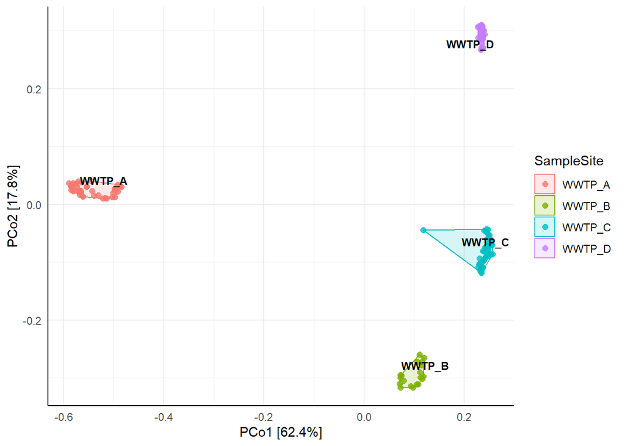

Qe1-b Make an ordination plot for a plant of your choice to explore the temporal dynamics of the overall microbial structure hint: subset first for your chosen WWTP

```r
plant_subset <- amp_subset_samples(dsn_midas, SampleSite == "WWTP_A")
```

```
## 100 samples and 4784 OTUs have been filtered
## Before: 139 samples and 12218 OTUs
## After: 39 samples and 7434 OTUs
```

```r
plant_subset$metadata$SampleDate <- as.Date(plant_subset$metadata$SampleDate, format = c("%d/%m/%Y"))


amp_ordinate(plant_subset,
             sample_trajectory = "SampleDate",
             sample_color_by = "SampleDate",
             sample_label_by = "Month")
```

```
## 7021 OTUs not present in more than 0.1% relative abundance in any sample have been filtered
## Before: 7434 OTUs
## After: 413 OTUs
```

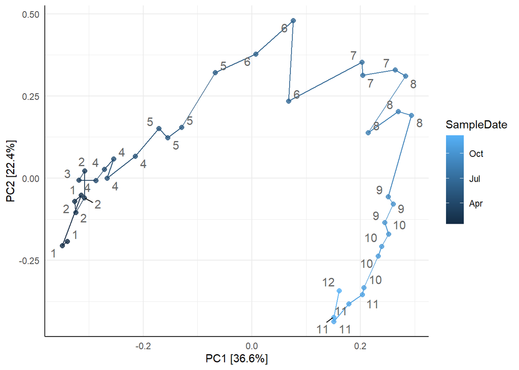

Qe2 How many of the top 25 genera are filamentous? hint: look into amp_heatmap(…, plot_functions = TRUE). Needs tax_aggregate at genus-level

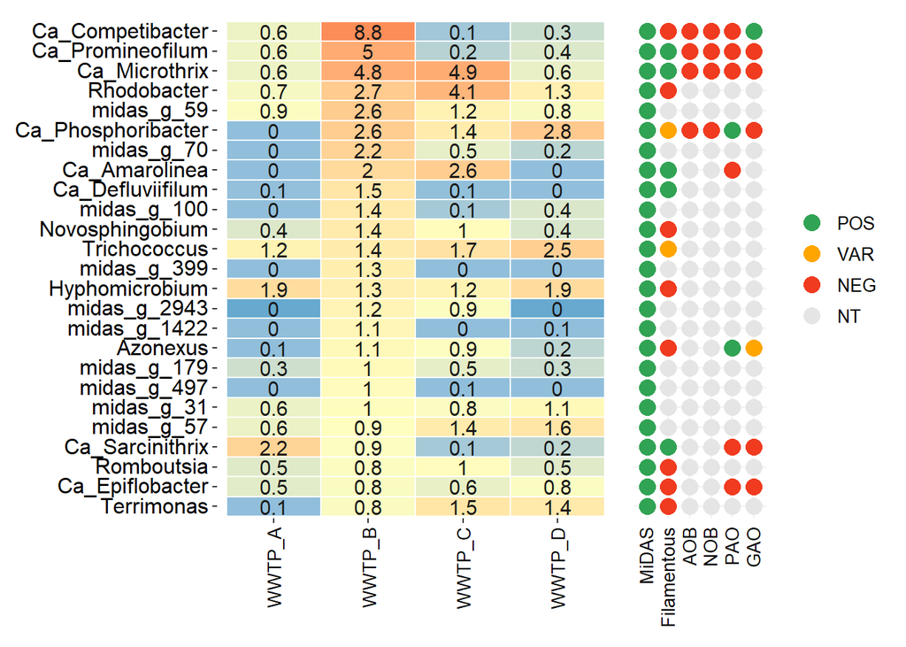

```r
amp_heatmap(dsn_midas,
             normalise = F,
            tax_aggregate = 'Genus',
            plot_functions = T,
            group_by = 'SampleSite',
            tax_show = 25,
            sort_by = 'WWTP_B')
```

Qe3 Which genera within Proteobacteria are the most abundant across all samples? hint: look into amp_subset_taxa()

```r
proteo <- amp_subset_taxa(dsn_midas,
                          tax_vector = 'p__Proteobacteria',
                          normalise = F)
```

```
## 9148 OTUs have been filtered
## Before: 12218 OTUs
## After: 3070 OTUs
```

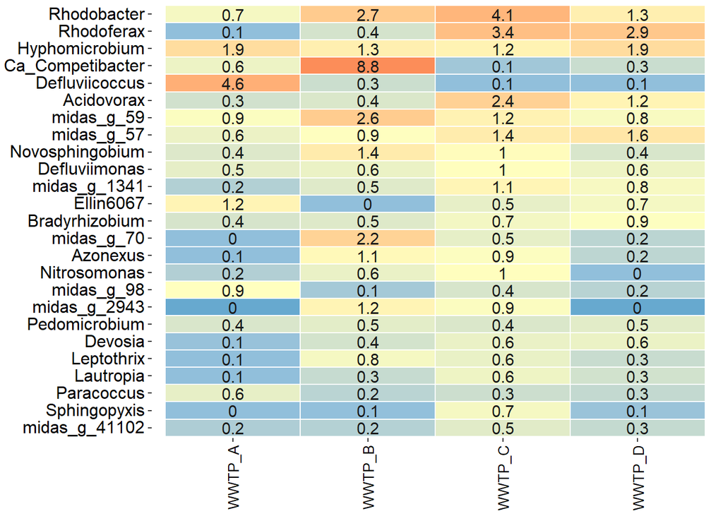

```r
amp_heatmap(proteo,
             normalise = F,
            tax_aggregate = 'Genus',
            group_by = 'SampleSite',
            tax_show = 25)
```

Qe4 Make alpha diversity analysis for the data (remember to rarefy at the same time) hint: look into amp_alpha_diversity()

```r
alpha <- amp_alpha_diversity(amp_subset_samples(d_midas,
                                minreads = 10000, normalise = F),
                            rarefy = 10000)
```

```
## 2 samples and 11 OTUs have been filtered
## Before: 141 samples and 12229 OTUs
## After: 139 samples and 12218 OTUs
```

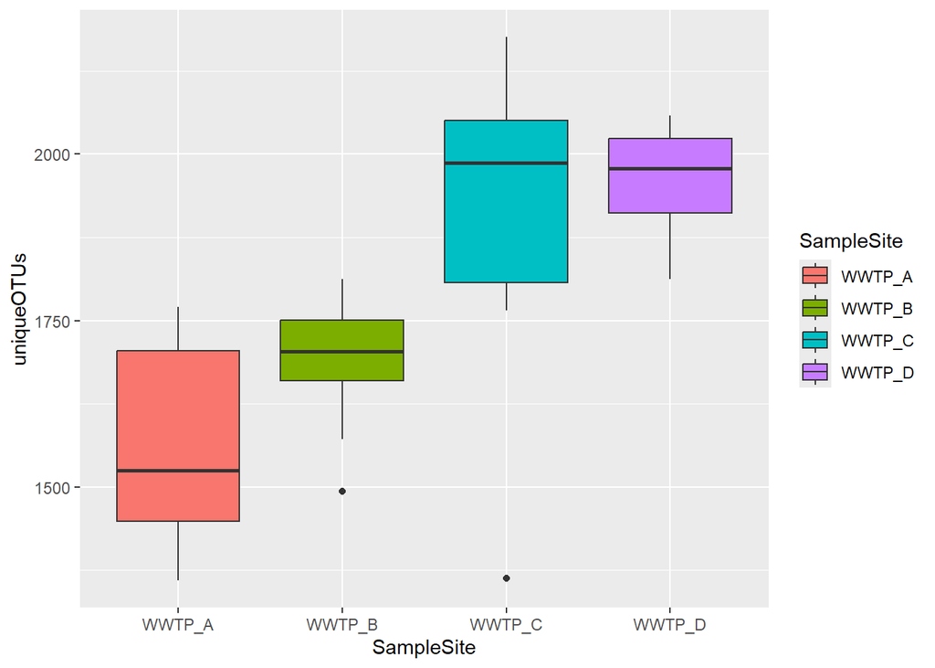

```r
ggplot(alpha) +
  geom_boxplot(aes(x=SampleSite, y = uniqueOTUs, fill = SampleSite),
              )
```

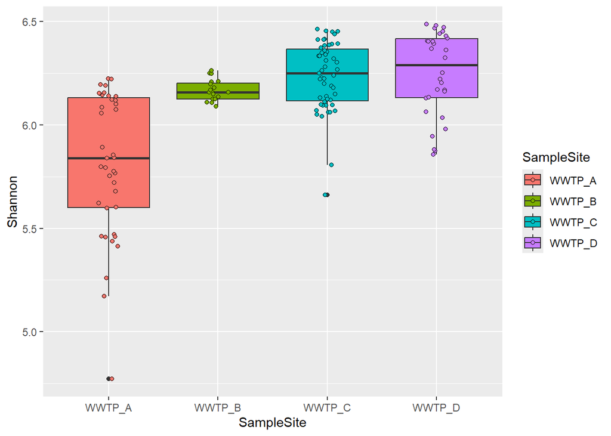

```r
ggplot(alpha) +
  geom_boxplot(aes(x=SampleSite, y = Shannon, fill = SampleSite)) +
  geom_point(aes(x=SampleSite, y = Shannon, fill = SampleSite),
             shape=21, position = position_jitter(width = 0.1))
```